# Task4

Tomas Kozlovskis

Friday, March 11, 2016

Mūsų užduotis buvo atlikti išsamią tiesinę regresiją. Lygtis reikalinga prekyboms agentams, kad geriau suprastų kokią įtaką skirtingos charakteristikos daro galutinei kainai.

Visų pirma, turime įsivesti duomenis į savo darbo aplinką ir juos apžvelgti.

```r
duom=read.csv2(file="C:/Users/TOMAS/Desktop/R/Destytojo/task4/data.csv")
head(duom)
```

```
##   kaina plotas aukstas garsoIzoliacija silumosLaidumas
## 1 55800     73       8        7.815161        7.606684
## 2 52700     73       1       11.176124       10.990996
## 3 53400     66       6        8.001061        8.460651
## 4 71600     86       2       10.421210       10.475897
## 5 46700     54       5        7.003640        6.687059
## 6 61200     75       4       11.187534       10.287033
##   atstumasIkiPrekybosCentro
## 1                0.80853061
## 2                0.08585002
## 3                0.68803387
## 4                0.72644151
## 5                1.14492192
## 6                0.88719906
```

Pasižiūrėję į duomenis, matome jog du rodikliai - garso izoliacija ir šilumos laidumas - gali būti koreliuoti, nes vienas nulemia kitą, t.y. kuo geriau apšiltintos sienos, tuo mažesnis šilumos laidumas, bet kartu ir garso izoliacija geresne.

```r
cor(duom$garsoIzoliacija, duom$silumosLaidumas)
```

```
## [1] 0.9535669
```

Suskaičiavę koreliacijos koeficientą, galime teigti, kad koreliacija egzistuoja, jos koeficientas yra lygus 0.95 ir yra gana didelis, todėl šilumos laidumas stipriai koreliuoja su garso izoliacija.

Dėl to, jog kintamieji yra koreliuoti, tų kintamųjų įverčiai gali būti paslinkti, todėl geriausia būtų šiuos du kintamuosius pakeisti į vieną, kuris yra garso izoliacijos ir šilumos laidumo vidurkis. Deja, šiuo atveju taip daryti negalime, dėl to, kad nežinome ar garso izoliacija ir šilumos laidumas yra pamatuoti vienodais kintamaisiais ir vienoje skalėje. Taigi, tam, kad išspręsti šią problemą, turime pašalinti vieno iš kintamųjų duomenis. Šiuo atveju, renkamės ištrinti garso izoliacijos duomenis, nes šilumos laidumas daro daugiau įtakos būsto kainai, negu garso izoliacija (senesnių namų kaina mažesnė, bet jų šilumos laidumas blogesnis, o garso izoliacija visų namų yra panaši).

```r
duom$garsoIzoliacija<-NULL
```

Visi duomenys turi išskirtis - reikšmes, kurios nuo didžiosios dalies reikšmių yra stipriai nutolusios. Tam, kad šios reikšmės stipriai neiškreiptų modelio, jas reikia surasti ir pašalinti. Tam naudosime “influence.measures” funkciją.

```r
kainaplotas<-lm(duom$kaina~duom$plotas)

kainaplotasaukstas<-lm(duom$kaina~duom$plotas+duom$aukstas)

kainaatstumas<-lm(duom$kaina~duom$atstumasIkiPrekybosCentro)

kainalaidumas<-lm(duom$kaina~duom$silumosLaidumas)

summary(influence.measures(kainaplotas))
```

```
## Potentially influential observations of
##   lm(formula = duom$kaina ~ duom$plotas) :
##
##     dfb.1_  dfb.dm$p dffit   cov.r   cook.d  hat
## 12   0.01   -0.01    -0.01    1.02_*  0.00    0.02
## 64   0.02   -0.02     0.02    1.03_*  0.00    0.02
## 80   0.02   -0.02     0.02    1.06_*  0.00    0.05_*
## 100 -0.21    0.20    -0.22    1.02_*  0.02    0.03_*
## 114  0.02   -0.02     0.02    1.03_*  0.00    0.02_*
## 132 -0.06    0.03    -0.14    0.97_*  0.01    0.00
## 152  0.03   -0.03     0.03    1.02_*  0.00    0.02
## 159 -0.20    0.19    -0.20    1.04_*  0.02    0.04_*
## 168  0.07   -0.07     0.08    1.03_*  0.00    0.02
## 194 -0.09    0.09    -0.09    1.05_*  0.00    0.04_*
## 197  0.02   -0.02    -0.02    1.03_*  0.00    0.02
## 213 -0.19    0.16    -0.22    0.97_*  0.02    0.01
## 220 -0.11    0.12     0.13    1.03_*  0.01    0.02_*
## 246 -0.01    0.01     0.01    1.03_*  0.00    0.02
## 253  2.09_* -1.96_*   2.12_*  0.39_*  1.38_*  0.03_*
## 254  1.16_* -1.27_*  -1.32_*  0.81_*  0.77_*  0.05_*
```

```r
summary(influence.measures(kainaplotasaukstas))
```

```
## Potentially influential observations of
##   lm(formula = duom$kaina ~ duom$plotas + duom$aukstas) :
##
##     dfb.1_  dfb.dm$p dfb.dm$k dffit   cov.r   cook.d  hat
## 80   0.03   -0.03     0.00     0.03    1.06_*  0.00    0.05_*
## 100 -0.20    0.25    -0.13    -0.29    1.02    0.03    0.04_*
## 114  0.01   -0.01     0.00     0.01    1.04_*  0.00    0.02
## 159 -0.20    0.22    -0.07    -0.24    1.04_*  0.02    0.04_*
## 194 -0.09    0.09    -0.01    -0.10    1.05_*  0.00    0.04_*
## 253  1.51_* -2.00_*   1.36_*   2.50_*  0.25_*  1.30_*  0.04_*
## 254  1.38_* -1.33_*  -0.60    -1.54_*  0.68_*  0.69    0.06_*
```

```r
summary(influence.measures(kainaatstumas))
```

```
## Potentially influential observations of
##   lm(formula = duom$kaina ~ duom$atstumasIkiPrekybosCentro) :
##
##     dfb.1_ dfb.d$IP dffit   cov.r   cook.d hat
## 73   0.00   0.01     0.01    1.03_*  0.00   0.02
## 77   0.03  -0.10    -0.10    1.03_*  0.01   0.03_*
## 80  -0.21   0.12    -0.21    0.95_*  0.02   0.01
## 90   0.00  -0.02    -0.02    1.03_*  0.00   0.02
## 100 -0.18   0.07    -0.19    0.95_*  0.02   0.00
## 121  0.01  -0.03    -0.03    1.05_*  0.00   0.04_*
## 129 -0.01   0.02     0.03    1.04_*  0.00   0.03_*
## 133  0.02  -0.05    -0.05    1.22_*  0.00   0.17_*
## 138  0.01  -0.02    -0.02    1.06_*  0.00   0.05_*
## 141  0.07  -0.26    -0.29_*  1.00    0.04   0.02
## 158  0.02  -0.06    -0.06    1.05_*  0.00   0.04_*
## 159 -0.18   0.05    -0.20    0.94_*  0.02   0.00
## 171  0.09  -0.20    -0.20    1.10_*  0.02   0.09_*
## 194 -0.14   0.01    -0.18    0.95_*  0.02   0.00
## 207 -0.02   0.05     0.05    1.10_*  0.00   0.09_*
## 214 -0.04   0.13     0.14    1.02_*  0.01   0.02
## 220  0.20  -0.12     0.20    0.97_*  0.02   0.01
## 243 -0.01   0.03     0.03    1.05_*  0.00   0.04_*
## 244 -0.07   0.21     0.22    1.03_*  0.02   0.03_*
## 246 -0.08   0.23     0.24    1.02    0.03   0.03_*
## 253  0.19  -0.07     0.21    0.94_*  0.02   0.00
```

```r
summary(influence.measures(kainalaidumas))
```

```
## Potentially influential observations of
##   lm(formula = duom$kaina ~ duom$silumosLaidumas) :
##
##     dfb.1_ dfb.dm$L dffit   cov.r   cook.d hat
## 21   0.15  -0.14     0.15    1.03_*  0.01   0.03_*
## 22  -0.05   0.06     0.07    1.03_*  0.00   0.02
## 29  -0.10   0.10    -0.10    1.04_*  0.01   0.03_*
## 41   0.24  -0.29    -0.31_*  1.03_*  0.05   0.04_*
## 42   0.00   0.00     0.00    1.03_*  0.00   0.02
## 58   0.00   0.00     0.00    1.04_*  0.00   0.03_*
## 60   0.07  -0.06     0.07    1.05_*  0.00   0.04_*
## 61  -0.03   0.04     0.04    1.03_*  0.00   0.02
## 77   0.03  -0.02     0.03    1.04_*  0.00   0.03_*
## 80  -0.08   0.02    -0.18    0.95_*  0.02   0.00
## 85   0.09  -0.11    -0.12    1.03_*  0.01   0.03_*
## 91  -0.02   0.02     0.02    1.03_*  0.00   0.02
## 96   0.23  -0.29    -0.32_*  1.00    0.05   0.02_*
## 100 -0.27   0.22    -0.28_*  0.97_*  0.04   0.01
## 131  0.04  -0.05    -0.05    1.03_*  0.00   0.02
## 135  0.04  -0.04     0.04    1.03_*  0.00   0.02
## 159 -0.26   0.21    -0.28_*  0.95_*  0.04   0.01
## 181  0.10  -0.09     0.10    1.03_*  0.00   0.02
## 194 -0.22   0.17    -0.25    0.96_*  0.03   0.01
## 213 -0.05   0.01    -0.14    0.97_*  0.01   0.00
## 220 -0.06   0.11     0.18    0.97_*  0.02   0.01
## 233 -0.02   0.02    -0.02    1.03_*  0.00   0.02
## 253  0.15  -0.09     0.22    0.93_*  0.02   0.00
```

Patikrinus kelių modelių, kuriuose kaina yra aiškinama per skirtingus kintamuosius (plotą, aukštą, atstumą iki parduotvės bei šilumos laidumą), “cook’s distance”, kuris informuoja apie išskirtis duomenyse, gautą iš funkcijos “influence.measures”, galime daryti išvadą, jog dvi eilutes (253,254) duomenų turime pašalinti.

```r
ids<-c(253,254)

duom<-duom[-ids,]
```

Sukuriame kelis modelius. . Atstumas iki prekybos centro yra pašalinamas visuose modeliuose, nes jis yra nereikšmingas.

```r
mod1<-lm(duom$kaina~duom$plotas+duom$aukstas+duom$silumosLaidumas)
summary(mod1)
```

```
##
## Call:
## lm(formula = duom$kaina ~ duom$plotas + duom$aukstas + duom$silumosLaidumas)
##
## Residuals:
##     Min      1Q  Median      3Q     Max
## -9323.0 -1579.4   114.8  1747.6  5759.2
##
## Coefficients:
##                      Estimate Std. Error t value Pr(>|t|)
## (Intercept)           8035.80     975.85   8.235 1.04e-14 ***
## duom$plotas            600.33      12.10  49.622  < 2e-16 ***
## duom$aukstas           318.23      63.50   5.011 1.03e-06 ***
## duom$silumosLaidumas   528.82      47.51  11.130  < 2e-16 ***
## ---
## Signif. codes:  0 '***' 0.001 '**' 0.01 '*' 0.05 '.' 0.1 ' ' 1
##
## Residual standard error: 2548 on 248 degrees of freedom
## Multiple R-squared:  0.9159, Adjusted R-squared:  0.9149
## F-statistic: 899.9 on 3 and 248 DF,  p-value: < 2.2e-16
```

```r
mod2<-lm(log(duom$kaina)~log(duom$plotas)+log(duom$aukstas)+log(duom$silumosLaidumas))
summary(mod2)
```

```
##
## Call:
## lm(formula = log(duom$kaina) ~ log(duom$plotas) + log(duom$aukstas) +
##     log(duom$silumosLaidumas))
##
## Residuals:
##       Min        1Q    Median        3Q       Max
## -0.222318 -0.033136  0.001482  0.033674  0.188209
##
## Coefficients:
##                           Estimate Std. Error t value Pr(>|t|)
## (Intercept)               7.832692   0.062815 124.695  < 2e-16 ***
## log(duom$plotas)          0.683311   0.014629  46.711  < 2e-16 ***
## log(duom$aukstas)         0.034553   0.004992   6.922 3.81e-11 ***
## log(duom$silumosLaidumas) 0.073782   0.007583   9.730  < 2e-16 ***
## ---
## Signif. codes:  0 '***' 0.001 '**' 0.01 '*' 0.05 '.' 0.1 ' ' 1
##
## Residual standard error: 0.0526 on 247 degrees of freedom
##   (1 observation deleted due to missingness)
## Multiple R-squared:  0.9063, Adjusted R-squared:  0.9051
## F-statistic: 796.1 on 3 and 247 DF,  p-value: < 2.2e-16
```

```r
mod3<-lm(duom$kaina~I(duom$plotas)+I(duom$aukstas)+I(duom$aukstas^2)+I(duom$silumosLaidumas))
summary(mod3)
```

```
##
## Call:
## lm(formula = duom$kaina ~ I(duom$plotas) + I(duom$aukstas) +
##     I(duom$aukstas^2) + I(duom$silumosLaidumas))
##
## Residuals:
##     Min      1Q  Median      3Q     Max
## -7571.2 -1629.5    13.8  1703.8  6150.0
##
## Coefficients:
##                         Estimate Std. Error t value Pr(>|t|)
## (Intercept)              4514.11    1015.09   4.447 1.32e-05 ***
## I(duom$plotas)            602.99      11.03  54.670  < 2e-16 ***
## I(duom$aukstas)          2139.76     259.82   8.236 1.04e-14 ***
## I(duom$aukstas^2)        -182.49      25.38  -7.191 7.61e-12 ***
## I(duom$silumosLaidumas)   527.79      43.29  12.191  < 2e-16 ***
## ---
## Signif. codes:  0 '***' 0.001 '**' 0.01 '*' 0.05 '.' 0.1 ' ' 1
##
## Residual standard error: 2322 on 247 degrees of freedom
## Multiple R-squared:  0.9304, Adjusted R-squared:  0.9293
## F-statistic: 825.9 on 4 and 247 DF,  p-value: < 2.2e-16
```

```r
mod4<-lm(duom$kaina~I(duom$plotas)+I(duom$aukstas^2)+I(duom$silumosLaidumas))
summary(mod4)
```

```
##
## Call:
## lm(formula = duom$kaina ~ I(duom$plotas) + I(duom$aukstas^2) +
##     I(duom$silumosLaidumas))
##
## Residuals:
##     Min      1Q  Median      3Q     Max
## -9923.9 -1388.9    53.5  1830.1  5398.1
##
## Coefficients:
##                         Estimate Std. Error t value Pr(>|t|)
## (Intercept)             8994.620    965.569   9.315  < 2e-16 ***
## I(duom$plotas)           600.998     12.424  48.373  < 2e-16 ***
## I(duom$aukstas^2)         21.250      6.368   3.337 0.000976 ***
## I(duom$silumosLaidumas)  518.953     48.764  10.642  < 2e-16 ***
## ---
## Signif. codes:  0 '***' 0.001 '**' 0.01 '*' 0.05 '.' 0.1 ' ' 1
##
## Residual standard error: 2616 on 248 degrees of freedom
## Multiple R-squared:  0.9113, Adjusted R-squared:  0.9103
## F-statistic: 849.7 on 3 and 248 DF,  p-value: < 2.2e-16
```

Geriausią modelį išsirenkame pagal “R-Squared” ir “Akaike’s Information Criteria” koeficientus.

```r
summary(mod1)$r.squared
```

```
## [1] 0.915869
```

```r
summary(mod2)$r.squared
```

```
## [1] 0.9062774
```

```r
summary(mod3)$r.squared
```

```
## [1] 0.9304345
```

```r
summary(mod4)$r.squared
```

```
## [1] 0.9113321
```

```r
AIC(mod1)
```

```
## [1] 4673.994
```

```r
AIC(mod3)
```

```
## [1] 4628.087
```

```r
AIC(mod4)
```

```
## [1] 4687.23
```

Patikrinę šiuos parametrus, renkamės trečią modelį “lm(formula = duom$kaina ~ I(duom$plotas) + I(duom$aukstas) + I(duom$aukstas^2) + I(duom$silumosLaidumas)”, nes jo R-Squared didžiausias iš visų, o AIC mažiausias.

Toliau tikrinsime mūsų pasirinkto modelio patikimumo parametrus.

Visų pirma tikriname modelio liekanų pasiskirstymo normalumą.

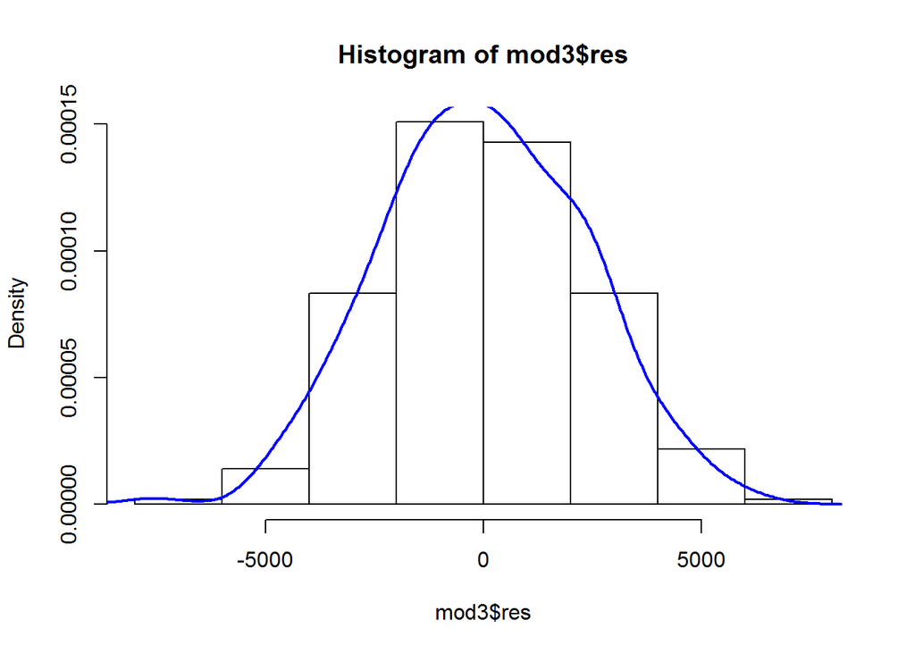

```r
histmod4<-hist(mod3$res, probability=TRUE)
lines(density(mod3$res), col=4, lwd=2)
```

```r
shapiro.test(mod3$res)
```

```
##
##  Shapiro-Wilk normality test
##
## data:  mod3$res
## W = 0.9968, p-value = 0.8877
```

P-Value yra daugiau už 0,05 todėl neatmetame nulinės testo hipotezės, kad tikrinami duomenys yra normaliai pasiskirstę. Taigi, liekanos yra normaliai pasiskirsčiusios.

Taip pat yra svarbu patikrinti, ar modelis nėra heteroskedastiškas.

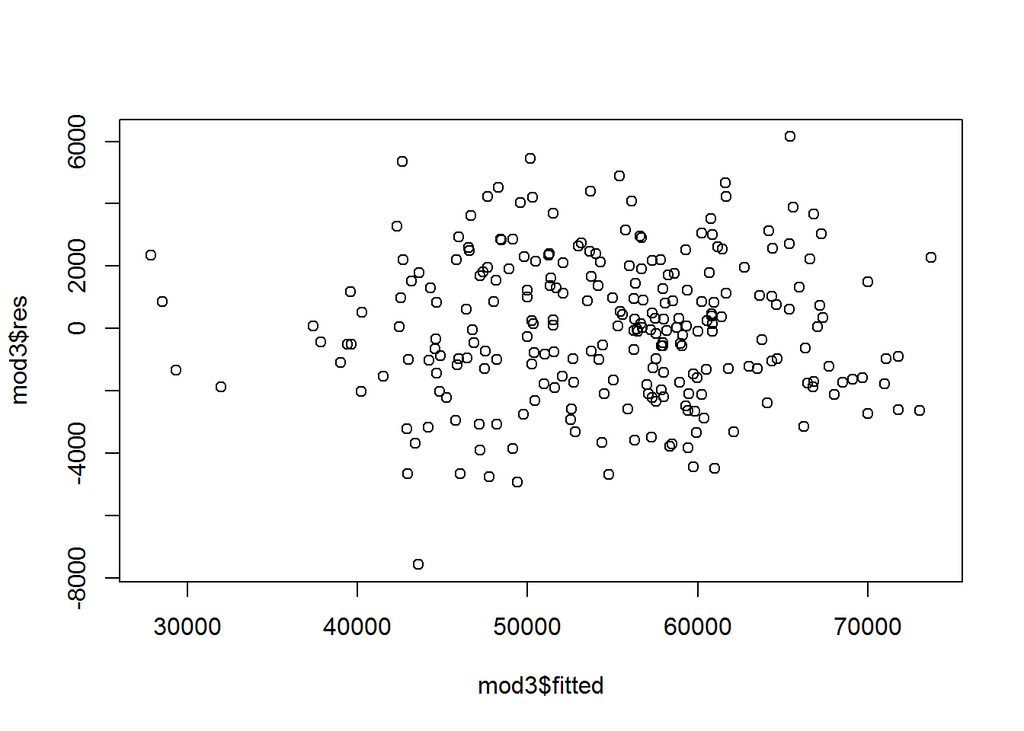

```r
plot(mod3$res~mod3$fitted)
library(car)
```

```r
ncvTest(mod3)
```

```
## Non-constant Variance Score Test
## Variance formula: ~ fitted.values
## Chisquare = 0.8245447    Df = 1     p = 0.3638547
```

Kadangi “Non-Constant Error Variance” testo p-value yra didesnis už 0,05, negalime atmesti nulinės hipotezės, teigiančios, jog modelis yra homoskedastiškas. Taigi, modelis heteroskedastiškumo problemų neturi.

```r
durbinWatsonTest(mod3)
```

```
##  lag Autocorrelation D-W Statistic p-value
##    1    -0.002247186      1.995758   0.972
##  Alternative hypothesis: rho != 0
```

Durbin-Watson testo p-value yra daugiau už 0,05, todėl negalime atmesti hipotezės, kad liekanos nėra autokoreliuotos.

Taigi, trečiasis modelis “lm(formula = duom$kaina ~ I(duom$plotas) + I(duom$aukstas) + I(duom$aukstas^2) + I(duom$silumosLaidumas)” yra patikimas pagal visus pagrindinius rodiklius. odėl galime jį naudoti nagrinėjant butų kainas.